# PA1_template

## Reproducible research assignment one

### 1. Loading and preprocessing data (creating a subset removing NA)

```r
file_act <- "activity.csv"
data_act  <- read.csv(file_act)
str(data_act)
```

```
## 'data.frame':    17568 obs. of  3 variables:
##  $ steps   : int  NA NA NA NA NA NA NA NA NA NA ...
##  $ date    : Factor w/ 61 levels "2012-10-01","2012-10-02",..: 1 1 1 1 1 1 1 1 1 1 ...
##  $ interval: int  0 5 10 15 20 25 30 35 40 45 ...
```

```r
data_act1 <- na.omit(data_act)  ## subset after removing NA data
str(data_act1)   ## checking the structure of the data
```

```
## 'data.frame':    15264 obs. of  3 variables:
##  $ steps   : int  0 0 0 0 0 0 0 0 0 0 ...
##  $ date    : Factor w/ 61 levels "2012-10-01","2012-10-02",..: 2 2 2 2 2 2 2 2 2 2 ...
##  $ interval: int  0 5 10 15 20 25 30 35 40 45 ...
##  - attr(*, "na.action")=Class 'omit'  Named int [1:2304] 1 2 3 4 5 6 7 8 9 10 ...
##   .. ..- attr(*, "names")= chr [1:2304] "1" "2" "3" "4" ...
```

### 2. Ignoring the missing values in the data set calculating the mean total number of steps taken per day

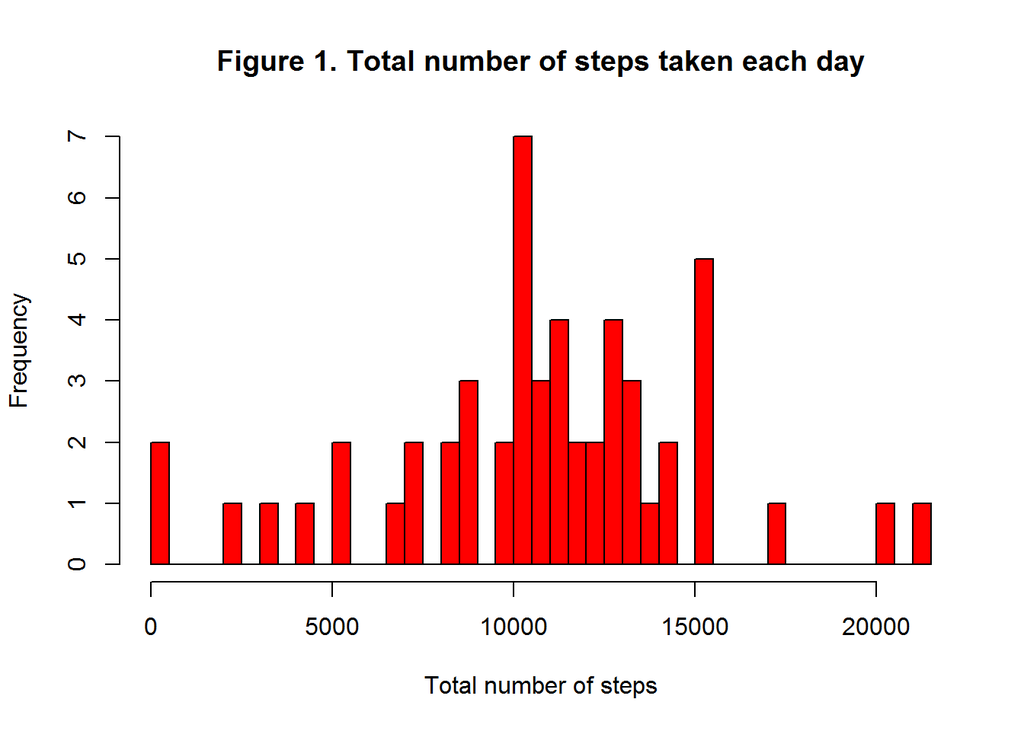

```r
      ##  (a) Plot a histogram of the total number of steps taken each day
sub1 <- NULL
sub1 <- data.frame(sub1)
sub1 <- data_act1[,c(1,2)]    ## Date and steps data only

aggr1 <- aggregate(.~date, FUN=sum, sub1)

hist(as.numeric(aggr1$steps), col="red", breaks=50,
     main= "Figure 1. Total number of steps taken each day",
     xlab= "Total number of steps")
```

```r
     ## (b) Calculate and report the mean and median of total number of
     ##     steps taken per day
stp_mean <- mean(aggr1$steps)
stp_median <- median(aggr1$steps)
```

The mean of the total number of steps taken per day is 1.0766 × 10<sup>4</sup> and the median of the total number of steps taken per day is 1.0765 × 10<sup>4</sup>.

### 3. Ignoring the missing values in the data set checking the average daily activity pattern

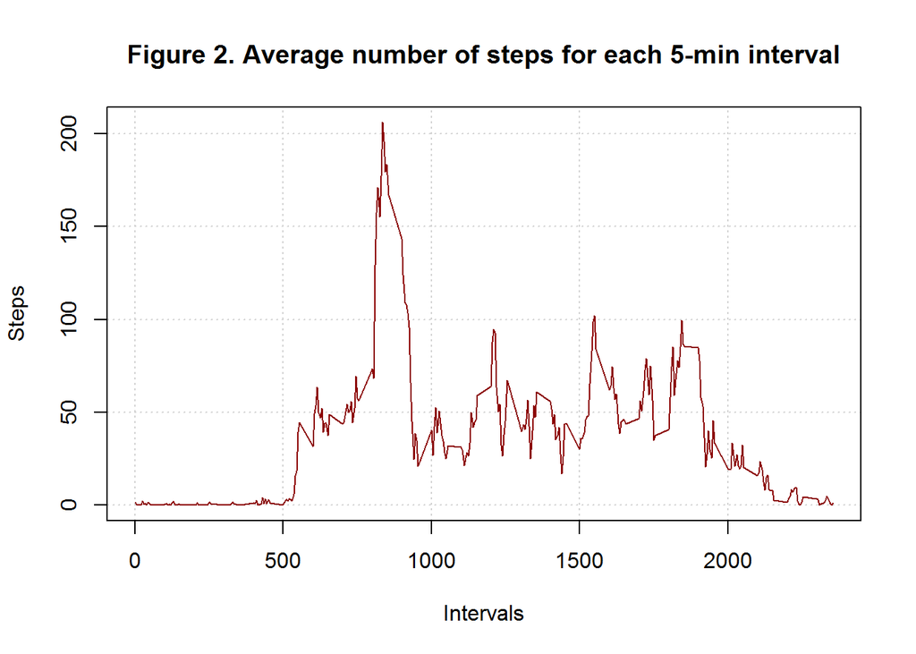

```r
     ## (a) plot time series polot (type='l') of the 5-min interval (x-axis)
     ##     and the averages number of steps taken, averaged across all days
     ##     (y-axis)
Sub1 <- NULL
Sub1 <- data.frame(Sub1)
Sub1 <- data_act1[,c(1,3)]  ## select the steps and interval data
Aggr1 <- aggregate(.~interval, FUN=mean, Sub1)  ## calculate mean

with(Aggr1,                 ## plot the time series average data
     plot(interval, steps,
          panel.first = grid(),
          type = 'l', col = "dark red",
          ylab = "Steps",
          xlab = "Intervals",
          main = "Figure 2. Average number of steps for each 5-min interval"))
```

```r
     ## (b) Determine the 5-min interval with the max number of steps
mxStp <- max(Aggr1$steps)
intvMaxStep <- subset(Aggr1, steps==mxStp)$interval
```

The interval with maximum number of steps (average over all the days) is interval 835.

### 4. Imputing the missing values and redoing the previous analysis

```r
     ## (a) Calculate and report the total number of missing values
data_act2 <- subset(data_act, is.na(steps)==TRUE)  ## subset with NA data
ttlNAobs <- nrow(data_act2)   ## total no of observations with missing values
```

The total number of observations with missing values for the steps column is 2304.

To substitute the data for missing values the strategy adopted here is to use the mean for that interval averaged over all the days for which data is available.

```r
     ## (b) Replace the missing values with mean of the interval
for(i in 1:ttlNAobs) {      ## Aggr1 contains the mean for each interval
  intPl <- data_act2[i,3]   ## get the interval data & set the corresponding mean
  data_act2[i,1] <- round(subset(Aggr1, interval==intPl)$steps)
  }
str(data_act2)    ## check the structure
```

```
## 'data.frame':    2304 obs. of  3 variables:
##  $ steps   : num  2 0 0 0 0 2 1 1 0 1 ...
##  $ date    : Factor w/ 61 levels "2012-10-01","2012-10-02",..: 1 1 1 1 1 1 1 1 1 1 ...
##  $ interval: int  0 5 10 15 20 25 30 35 40 45 ...
```

```r
     ## (c) Create a new data set with the missing data filled in
new_dat <- rbind(data_act1, data_act2)
str(new_dat)      ## check the structure of the new data frame
```

```
## 'data.frame':    17568 obs. of  3 variables:
##  $ steps   : num  0 0 0 0 0 0 0 0 0 0 ...
##  $ date    : Factor w/ 61 levels "2012-10-01","2012-10-02",..: 2 2 2 2 2 2 2 2 2 2 ...
##  $ interval: int  0 5 10 15 20 25 30 35 40 45 ...
##  - attr(*, "na.action")=Class 'omit'  Named int [1:2304] 1 2 3 4 5 6 7 8 9 10 ...
##   .. ..- attr(*, "names")= chr [1:2304] "1" "2" "3" "4" ...
```

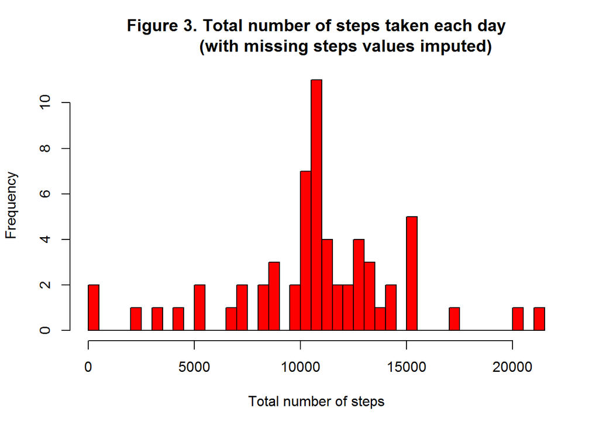

```r
     ## (d) Make a histogram of the total number of steps taken each day
sub2 <- NULL
sub2 <- data.frame(sub2)
sub2 <- new_dat[,c(1,2)]
aggr1 <- aggregate(.~date, FUN=sum, sub2)

hist(aggr1$steps, col="red", breaks=50,
     main= "Figure 3. Total number of steps taken each day
            (with missing steps values imputed)",
     xlab= "Total number of steps")
```

```r
     ## (e) Calculate and report the mean and median of total number of
     ##     steps taken per day
stn_mean <- mean(aggr1$steps)
stn_median <- median(aggr1$steps)
```

Based on the imputed data the mean of the total number of steps taken per day is 1.0766 × 10<sup>4</sup> and the median of the total number of steps taken per day is 1.0762 × 10<sup>4</sup>. There is hardly any difference from the mean and median of the data set without the missing values.

But comparing figure 1 with figure 3 we can observe that the frequency of certain ranges (bins) have increased, because we have substituted the missing values with the mean for that interval over all the days. There is hardly any change in the shape of the histogram for the two data sets.

### 5. Finding the differences in activity patterns between weekdays and weekends

```r
     ## Create a new factor variable in the dataset with two levels - "weekday"
     ## and "weekend" indicating whether a given date is weekday or weekend day
Sys.setlocale("LC_TIME","English")  ## changing the locale to English
```

```
## [1] "English_United States.1252"
```

```r
for(i in 1:ttlNAobs) {
  dt1 <- weekdays(as.Date(new_dat[i,2]), abbreviate=TRUE) ## get the day of the week
  if(dt1 == "Sat" | dt1 == "Sun")
    new_dat$wkday[i] <- "weekend"
  else
    new_dat$wkday[i] <- "weekday"
  }
new_dat$wkday <- as.factor(new_dat$wkday)
str(new_dat)  ## checking the structure of the new data set
```

```
## 'data.frame':    17568 obs. of  4 variables:
##  $ steps   : num  0 0 0 0 0 0 0 0 0 0 ...
##  $ date    : Factor w/ 61 levels "2012-10-01","2012-10-02",..: 2 2 2 2 2 2 2 2 2 2 ...
##  $ interval: int  0 5 10 15 20 25 30 35 40 45 ...
##  $ wkday   : Factor w/ 2 levels "weekday","weekend": 1 1 1 1 1 1 1 1 1 1 ...
##  - attr(*, "na.action")=Class 'omit'  Named int [1:2304] 1 2 3 4 5 6 7 8 9 10 ...
##   .. ..- attr(*, "names")= chr [1:2304] "1" "2" "3" "4" ...
```

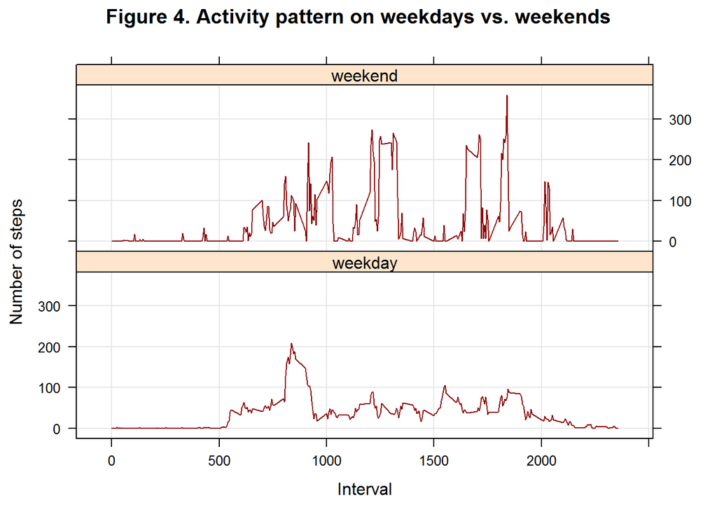

```r
  ## calculate the mean of each interval and weekdays level
Aggr3 <- aggregate(.~interval+wkday, FUN=mean, new_dat)

  ## make panel plot of the above data
library(lattice)
xyplot(steps~interval|wkday,
       grid = TRUE,
       type = "l", col = "dark red",
       ylab = "Number of steps",
       xlab = "Interval",
       data = Aggr3,
       main = "Figure 4. Activity pattern on weekdays vs. weekends",
       layout = c(1,2))
```